# JS加密、混淆

### js加密，js混淆，js逆向机制

- url：https://www.aqistudy.cn/html/city_detail.html
- 分析：
  - 1.当我们修改了页面的查询条件后，点击查询按钮，在抓包工具中会捕获到两个一样的数据包，我们只要能破解其中一个数据包的内容剩下一个也可以同理破解。
    - 请求的url：https://www.aqistudy.cn/apinew/aqistudyapi.php
    - 请求方式：post
    - 请求参数：d：一组动态变化且加密的数据值
    - 返回的响应数据就是我们想要捕获的空气指标数据
      - 响应数据也被加密，是一组被加密的密文数据。我们必须将密文数据解密成原文数据才可以被我们使用。
  - 2.我们在点击查询按钮后，发现页面没有全局刷新，则表示点击查询按钮后发起的是ajax请求。
    - 发起的ajax请求对应的数据包就是我们在step1表示的数据包。
    - 该ajax请求发送的时候请求的：
      - url：https://www.aqistudy.cn/apinew/aqistudyapi.php
      - 请求方式：post
      - 请求参数：d：一组动态变化且加密的数据值
      - 响应回来的数据也是一组加密的密文数据
    - 请求回来的数据是一组密文数据，但是在前台页面中显示的为原文数据？
      - 原因在于前台将响应回来的密文数据进行解密。
        - 价值的信息：在该网站的相关数据包中是存在解密方案，我们只需要将其解密方法获取，对密文进行解密即可。
  - 3.点击查询按钮发起的是ajax请求，该请求在该网站中一定是用js或者jQuery写的，在ajax请求的代码中，可以看到那些具体的操作：
    - 请求的url
    - 请求的方式
      - 请求的url和请求方式可以从抓包工具中捕获
    - 携带的请求参数
      - 可以从ajax的代码中获取
      - 为什么请求参数不可以从抓包工具中获取？
        - 应为该参数是动态变化且加密
    - 请求回来的数据对应的回调函数
      - 函数的参数就是请求到的响应数据（加密的密文数据），该函数会对拿到的密文数据进行解密，将解密后的原文动态显示在前台页面中。
    - 重点：只要能够找到点击查询按钮对应的ajax请求代码后，就可以知道动态变化且加密的请求参数如何生成。那么我们就可以使用该方式动态生成一组请求参数，然后基于指定的url进行请求发送，获取加密的响应数据。获取的密文数据就可以通过ajax请求代码中的回调/匿名函数的操作中获取解密方案，使用该方案对加密的响应数据解密即可。【大功告成】
- 操作：找寻ajax请求的代码
  - 方案：获取搜索按钮对应的点击事件绑定的函数即可。
    - 最好使用火狐浏览器找寻点击事件的函数代码。

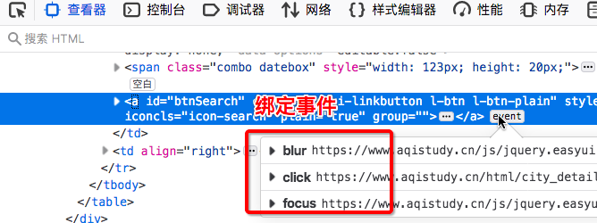

[figure not shown]

- 点击搜索按钮对应的点击事件函数名叫做getData，接下来就进入该函数内部找寻ajax请求代码。
  - 找到了getData函数的实现：
    - 没有发现ajax代码实现
    - 发现函数内部调用了另外的两个函数 getAQIData();getWeatherData();
    - ajax代码的实现一定是在上述的两个函数内部
    - 有价值的信息：
      - type=="HOUR"：查询时间是以小时为单位
        - 进入到getAQIData();getWeatherData()函数内部找寻ajax代码实现：
        - 在这两个函数内部没有发现ajax代码
        - 调用了一个叫做getServerData()函数，那么ajax代码一定存在getServerData函数中。
        - getServerData的参数：
          - method：GETDETAIL字符串
          - param：字典，有四组键值对
            - - param.city = city; - param.type = type; - param.startTime = startTime; - param.endTime = endTime;
          - 回调函数
          - 0.5
  - 进入到getServerData函数内部找寻ajax代码：
    - 函数实现的找寻，需要在抓包工具中进行全局搜索。
    - 找到的结果看上去像是密文，看不懂。
    - js混淆：
      - 在网站后台，关键的重要的js函数的实现为了保密，一般会对这些js函数代码进行混淆（加密），所以我们需要对js混淆的代码进行反混淆，将加密的js函数进行解密。
    - 反混淆：
      - 网址：http://www.bm8.com.cn/jsConfusion/
- getServerData反混淆后的实现：

```python
function getServerData(method, object, callback, period) {
        const key = hex_md5(method + JSON.stringify(object));
        const data = getDataFromLocalStorage(key, period);
        if (!data) {
            var param = getParam(method, object);
            $.ajax({
                url: '../apinew/aqistudyapi.php',
                data: {
                    d: param#加密且动态变化的请求参数
                },
                type: "post",
                #data请求到的加密的响应数据
                success: function (data) {
                    #decodeData就是对加密的响应数据进行解密
                    data = decodeData(data);
                    obj = JSON.parse(data);
                    if (obj.success) {
                        if (period > 0) {
                            obj.result.time = new Date().getTime();
                            localStorageUtil.save(key, obj.result)
                        }
                        callback(obj.result)
                    } else {
                        console.log(obj.errcode, obj.errmsg)
                    }
                }
            })
        } else {
            callback(data)
        }
    }
```

- 分析getServerData函数实现中的ajax代码：
  - 动态变化且加密的请求参数
    - getParam(method, object)
      - method：GETDETAIL
      - object：
        - param：字典，有四组键值对
          - param.city = city;
          - param.type = type;
          - param.startTime = startTime;
          - param.endTime = endTime;
  - decodeData(data):将data这个加密的响应数据进行解密
    - 是需要调用该函数就可以对加密的响应数据进行解密
  - 总结：
    - 调用getParam后就可以获取加密变化的请求参数
    - 调用decodeData就可以将响应数据进行解密
  - 问题：
    - 上述的两个函数是js函数，我们现在写的爬虫程序是python，python如何调用js函数呢？
    - python如何调用js函数
      - 方式1：
        - 可以将js函数改写为python函数
      - 方式2：
        - 使用相关模块进行js逆向
        - PyExecJS介绍：PyExecJS 是一个可以使用 Python 来模拟运行 JavaScript 的库。我们需要pip install PyExecJS对其进行环境安装。除此之外还需要安装nodejs的开发环境。
          - js逆向：
          - 将js函数改写为python函数
- PyExecJS的使用
  - 1.需要将待执行的js函数的全部定义存储到一个js源文件中
  - 2.模拟执行js源文件中的js函数
    - 1.加载js源文件中的代码
    - 2.将js源文件中的代码进行编译

```python
#使用模块进行js逆向，模拟调用js源文件（test.js）中的getParams函数获取动态变化加密的请求参数
import execjs
#实例化一个对象
node = execjs.get()
# Params
method = 'GETDETAIL'
city = '北京'
type = 'HOUR'
start_time = '2018-01-25 00:00:00'
end_time = '2018-01-25 23:00:00'

# Compile javascript
file = 'test.js'#待加载编译的js源文件
#加载编译js源文件中的js代码
ctx = node.compile(open(file,encoding='utf-8').read())

# Get params
js = 'getPostParamCode("{0}", "{1}", "{2}", "{3}", "{4}")'.format(method, city, type, start_time, end_time)
#eval表示模拟执行编译好的js函数
params = ctx.eval(js)
print(params)#返回是加密变化的请求参数
```

[output not shown]

- 可以对ajax进行请求发送

```python
import execjs
import requests

node = execjs.get()
# Params
method = 'GETDETAIL'
city = '北京'
type = 'HOUR'
start_time = '2018-01-25 00:00:00'
end_time = '2018-01-25 23:00:00'

# Compile javascript
file = 'test.js'#待加载编译的js源文件
#加载编译js源文件中的js代码
ctx = node.compile(open(file,encoding='utf-8').read())

# Get params
js = 'getPostParamCode("{0}", "{1}", "{2}", "{3}", "{4}")'.format(method, city, type, start_time, end_time)
#eval表示模拟执行编译好的js函数
params = ctx.eval(js)

#发起post请求
url = 'https://www.aqistudy.cn/apinew/aqistudyapi.php'
response_text = requests.post(url, data={'d': params}).text
print(response_text)#返回加密的响应数据
```

```
n8Un3OpswjBlUIgnbmQ+Npphg68NTuGGzboCX28bX4NaHfiL5LH6CmmfDxyY74+E7OD4v/JpTW7vrVHQDi9Pev5HYg9Fcuso1ZVkZhd910MsBJkkjnJuAZomwI+NTEgwhmDiZkYK6YuIWq3X0qgUrQ==
```

- 加密的响应数据获取了，接下来，模拟执行decodeData的js函数进行加密响应数据的解密

```python
import execjs
import requests

node = execjs.get()
# Params
method = 'GETDETAIL'
city = '北京'
type = 'HOUR'
start_time = '2018-01-25 00:00:00'
end_time = '2018-01-25 23:00:00'

# Compile javascript
file = 'test.js'#待加载编译的js源文件
#加载编译js源文件中的js代码
ctx = node.compile(open(file,encoding='utf-8').read())

# Get params
js = 'getPostParamCode("{0}", "{1}", "{2}", "{3}", "{4}")'.format(method, city, type, start_time, end_time)
#eval表示模拟执行编译好的js函数
params = ctx.eval(js)

#发起post请求
url = 'https://www.aqistudy.cn/apinew/aqistudyapi.php'
#返回加密的响应数据
response_text = requests.post(url, data={'d': params}).text


#模拟执行decodeData来对密文数据进行解密
js = 'decodeData("{0}")'.format(response_text)
decrypted_data = ctx.eval(js)
print(decrypted_data)
```

- 返回的原文形式的响应数据： {"success":true,"errcode":0,"errmsg":"success","result":{"success":true,"data":{"total":24,"rows":[{"time":"2018-01-25 00:00:00","temp":"-7","humi":"35","wse":"1","wd":"\u4e1c\u5317\u98ce","tq":"\u6674"},{"time":"2018-01-25 01:00:00","temp":"-9","humi":"38","wse":"1","wd":"\u897f\u98ce","tq":"\u6674"},{"time":"2018-01-25 02:00:00","temp":"-10","humi":"40","wse":"1","wd":"\u4e1c\u5317\u98ce","tq":"\u6674"},{"time":"2018-01-25 03:00:00","temp":"-8","humi":"27","wse":"2","wd":"\u4e1c\u5317\u98ce","tq":"\u6674"},{"time":"2018-01-25 04:00:00","temp":"-8","humi":"26","wse":"2","wd":"\u4e1c\u98ce","tq":"\u6674"},{"time":"2018-01-25 05:00:00","temp":"-8","humi":"23","wse":"2","wd":"\u4e1c\u5317\u98ce","tq":"\u6674"},{"time":"2018-01-25 06:00:00","temp":"-9","humi":"27","wse":"2","wd":"\u4e1c\u5317\u98ce","tq":"\u591a\u4e91"},{"time":"2018-01-25 07:00:00","temp":"-9","humi":"24","wse":"2","wd":"\u4e1c\u5317\u98ce","tq":"\u591a\u4e91"},{"time":"2018-01-25 08:00:00","temp":"-9","humi":"25","wse":"2","wd":"\u4e1c\u98ce","tq":"\u6674\u8f6c\u591a\u4e91\u8f6c\u591a\u4e91\u95f4\u6674"},{"time":"2018-01-25 09:00:00","temp":"-8","humi":"21","wse":"3","wd":"\u4e1c\u5317\u98ce","tq":"\u6674\u8f6c\u591a\u4e91\u8f6c\u591a\u4e91\u95f4\u6674"},{"time":"2018-01-25 10:00:00","temp":"-7","humi":"19","wse":"3","wd":"\u4e1c\u5317\u98ce","tq":"\u6674\u8f6c\u591a\u4e91\u8f6c\u591a\u4e91\u95f4\u6674"},{"time":"2018-01-25 11:00:00","temp":"-6","humi":"18","wse":"3","wd":"\u4e1c\u5317\u98ce","tq":"\u591a\u4e91"},{"time":"2018-01-25 12:00:00","temp":"-6","humi":"17","wse":"3","wd":"\u4e1c\u5317\u98ce","tq":"\u591a\u4e91"},{"time":"2018-01-25 13:00:00","temp":"-5","humi":"17","wse":"2","wd":"\u4e1c\u5317\u98ce","tq":"\u591a\u4e91"},{"time":"2018-01-25 14:00:00","temp":"-5","humi":"16","wse":"2","wd":"\u4e1c\u98ce","tq":"\u591a\u4e91"},{"time":"2018-01-25 15:00:00","temp":"-5","humi":"15","wse":"2","wd":"\u5317\u98ce","tq":"\u591a\u4e91"},{"time":"2018-01-25 16:00:00","temp":"-5","humi":"16","wse":"2","wd":"\u4e1c\u5317\u98ce","tq":"\u591a\u4e91"},{"time":"2018-01-25 17:00:00","temp":"-5","humi":"16","wse":"2","wd":"\u4e1c\u98ce","tq":"\u591a\u4e91"},{"time":"2018-01-25 18:00:00","temp":"-6","humi":"18","wse":"2","wd":"\u4e1c\u98ce","tq":"\u6674\u95f4\u591a\u4e91"},{"time":"2018-01-25 19:00:00","temp":"-7","humi":"19","wse":"2","wd":"\u4e1c\u98ce","tq":"\u6674\u95f4\u591a\u4e91"},{"time":"2018-01-25 20:00:00","temp":"-7","humi":"19","wse":"1","wd":"\u4e1c\u98ce","tq":"\u6674\u95f4\u591a\u4e91"},{"time":"2018-01-25 21:00:00","temp":"-7","humi":"19","wse":"0","wd":"\u5357\u98ce","tq":"\u6674\u95f4\u591a\u4e91"},{"time":"2018-01-25 22:00:00","temp":"-7","humi":"22","wse":"1","wd":"\u4e1c\u5317\u98ce","tq":"\u6674\u95f4\u591a\u4e91"},{"time":"2018-01-25 23:00:00","temp":"-9","humi":"27","wse":"1","wd":"\u897f\u5357\u98ce","tq":"\u6674\u95f4\u591a\u4e91"}]}}}